# Project proposal

AF

```r
library(knitr)
library(tidyverse)
library(broom)
library(htmltools)
library(ggrepel)
library(ggpubr)
library(stringr)
library(scales)
library(lubridate)
library(gganimate)
library(gapminder)
library(GGally)
library(cowplot)
```

## 1. Introduction

Everyone loves a good movie!

Movie industry is a multi-billion-dollar business. Lots of movies are being released in every year. All of these movies have different features, budget, cast crew, etc. but one thing is in common - all want to be successful. Success of a movie depends on various factors of past and present. Identifying the right factors can predict the profitability, rating and award winning of a movie that we define as the most important criteria for movie’s success. Some of the factors in predicting movie success are budget, actors, director, IMDB vote count, social fan following and likes, etc. Movie’s success prediction plays an indispensable job in the film industry, some researchers over the years predicted success of a movie by it’s profitability or IMDB rating, In this project, we will test various factors and find a movie’s success model that consider both in addition to award winning of a movie. The success can not be predicted based on one specific factor, what makes it harder to analyze. Our main goal in this project is to find out what are the most significant factors and connections that influence our success indicators by analysis and manipulations of our data, what causes the difference between the ups and downs of the success indicators, and try to explain the reasons for this in a scientific and research way.

## 2. Data

```r
undesired <- c('color','actor_3_facebook_likes',"actor_2_name","actor_3_name","facenumber_in_poster","plot_keywords" ,"movie_imdb_link","num_user_for_reviews","language","country","actor_2_facebook_likes","aspect_ratio")
```

```r
Oscar_file <- read.csv('../data/the_oscar_award.csv')%>% rename(movie_title = film)%>%
select(movie_title,winner) %>%
filter(winner == "True") %>% distinct()  #filter Oscar winners

Movies_file_5000 <- read.csv('../data/movie_metadata.csv')
Movies_file_5000$movie_title <- substring(Movies_file_5000$movie_title, 1, nchar(Movies_file_5000$movie_title)-2)  ##remove suffix from movie title

movies = merge(x = Movies_file_5000, y =  Oscar_file, by = "movie_title", all.x = TRUE) %>%
select(-one_of(undesired)) %>%
mutate(ROI = (gross/budget)) #join and remove/add columns

movies["winner"][is.na(movies["winner"])] <- 0
movies["winner"][movies["winner"] == "True"] <- 1
movies = movies %>% drop_na(gross) %>% drop_na(budget)

movies$genres = str_extract(movies$genres,"(\\w+)") # extract only one genre
movies$winner = as.numeric(as.character(movies$winner))
movies =  movies %>% rename(main_actor = actor_1_name, main_actor_facebook_likes = actor_1_facebook_likes)

mean_gross = mean(movies$gross)
mean_imdb = round(mean(movies$imdb_score),3)

movies$succeed = ifelse(movies$gross < mean_gross,0,
                        ifelse(movies$imdb_score < mean_imdb,0,
                               ifelse(movies$winner != 1,0,1)))

glimpse(movies)
```

```
## Rows: 3,891
## Columns: 19
## $ movie_title               <chr> "[Rec] 2", "\303†on Flux", "10 Cloverfield L~
## $ director_name             <chr> "Jaume Balaguer\303³", "Karyn Kusama", "Dan ~
## $ num_critic_for_reviews    <int> 222, 178, 411, 1, 133, 84, 26, 113, 597, 450~
## $ duration                  <int> 85, 93, 104, 111, 97, 100, 107, 108, 134, 94~
## $ director_facebook_likes   <int> 57, 45, 16, 0, 19, 36, 53, 212, 0, 0, 56, 0,~
## $ main_actor_facebook_likes <int> 37, 9000, 14000, 1000, 23000, 2000, 954, 969~
## $ gross                     <int> 27024, 25857987, 71897215, 14616, 38176108, ~
## $ genres                    <chr> "Horror", "Action", "Drama", "Drama", "Comed~
## $ main_actor                <chr> "Jonathan D. Mellor", "Charlize Theron", "Br~
## $ num_voted_users           <int> 55597, 110614, 126893, 314, 222099, 26413, 5~
## $ cast_total_facebook_likes <int> 73, 10185, 14504, 2059, 37907, 4182, 2512, 2~
## $ content_rating            <chr> "R", "PG-13", "PG-13", "R", "PG-13", "G", "R~
## $ budget                    <dbl> 5.6e+06, 6.2e+07, 1.5e+07, 1.2e+07, 1.6e+07,~
## $ title_year                <int> 2009, 2005, 2016, 2015, 1999, 2000, 2006, 20~
## $ imdb_score                <dbl> 6.6, 5.5, 7.3, 7.5, 7.2, 4.8, 6.4, 5.6, 8.1,~
## $ movie_facebook_likes      <int> 4000, 0, 33000, 26000, 10000, 372, 294, 0, 8~
## $ winner                    <dbl> 0, 0, 0, 0, 0, 0, 0, 0, 1, 0, 0, 0, 0, 0, 0,~
## $ ROI                       <dbl> 0.004825714, 0.417064306, 4.793147667, 0.001~
## $ succeed                   <dbl> 0, 0, 0, 0, 0, 0, 0, 0, 1, 0, 0, 0, 0, 0, 0,~
```

### Data README

```r
cat(readLines('../data/README.md'), sep = '\n')
```

```
## # SISE2601 Project data description
## ================
## Team name:AF
##
## Lets explore every dimension:
##
## 1. movie_title: Title of the Movie
##
## 2. director_name: Name of the Director of the Movie
##
## 3. num_critic_for_reviews: Number of critical reviews on imdb
##
## 4.  duration: Duration in minutes
##
## 5. director_facebook_likes: Number of likes of the director on his Facebook Page
##
## 6. main_actor_facebook_likes: Number of likes of the main actor on his/her Facebook Page
##
## 7. gross: Gross earnings of the movie in Dollars
##
## 8. genres: film categorization like "Animation", "Comedy", "Romance", "Horror", "Sci-Fi", "Action", "Family"
##
## 9. main_actor: Primary actor starring in the movie
##
## 10. num_voted_users: Number of people who voted for the movie
##
## 11. cast_total_facebook_likes : Total number of facebook likes of the entire cast of the movie
##
## 12. content_rating : Content rating of the movie. include the next values :
## G - General Audiences. All ages admitted. Nothing that would offend parents for viewing by children.
## PG - Parental Guidance Suggested. Some material may not be suitable for children. Parents urged to give "parental guidance". May contain some material parents might not like for their young children.
## PG-13 - Parents Strongly Cautioned. Some material may be inappropriate for children under 13. Parents are urged to be cautious. Some material may be inappropriate for pre-teenagers.
## R - Restricted. Under 17 requires accompanying parent or adult guardian. Contains some adult material. Parents are urged to learn more about the film before taking their young children with them.
## NC-17 - Adults Only. No One 17 and Under Admitted. Clearly adult. Children are not admitted.
##
## 13.budget: Budget of the movie in Dollars
##
## 14.title_year : The year in which the movie is released (1916:2016)
##
## 15.imdb_score: IMDB Score of the movie on IMDB
##
## 16.movie_facebook_likes: Number of Facebook likes in the movie page
##
## 17.winner: 1- if actor/director won an oscar, 0- if not.
##
## 18. ROI: Return on investment, is a mathematical formula that use to evaluate investments and judge how well a particular investment has performed compared to others.
## formula: ROI = Net income / Cost of investment
##
## 19. succeed: if movie succeed or not by our three parameters: above the average gross, above the average imbd score and won Oscar title
## 1-succeed
## 0-not
```

```r
cat("The data contain",ncol(movies), "variables")
```

```
## The data contain 19 variables
```

```r
cat("\n")
```

```r
cat("The data contain",nrow(movies), "movies")
```

```
## The data contain 3891 movies
```

## 3. Preliminary results

In the next section we will examine some charts that might help us get a little sense about our data and the way we will analyze it further in our research. First of all, we want to get a quick view on our data distribution, so we will extract the number of Oscar winners and the mean value of two factors: gross and IMDB score, these factors are the factors that we mentioned above as critic for success.

```r
cat("The number of Oscar winner movies is:",sum(movies$winner))
```

```
## The number of Oscar winner movies is: 334
```

```r
cat("\n")
```

```r
cat("The mean gross is:",mean_gross, "$")
```

```
## The mean gross is: 51054995 $
```

```r
cat("\n")
```

```r
cat("The mean IMDB score is:",mean_imdb)
```

```
## The mean IMDB score is: 6.464
```

```r
cat("\n")
```

```r
cat("The number of successful movies is:",sum(movies$succeed))
```

```
## The number of successful movies is: 191
```

After we calculated our decisive values for success, we can see that there is not many observation for Oscar winner movies, so it will be hard to get a reliable insights from this amount of observation, so we will divide the data into few groups:

successful - gross above average, score above average and won the Oscar without winner - gross above average, score above average and did not win the Oscar without score - gross above average, score underneath average and won the Oscar without gross - gross underneath average, score above average and won the Oscar only winner - gross underneath average, score underneath average and won the Oscar only score - gross underneath average, score above average and did not win the Oscar only gross - gross above average, score underneath average and did not win the Oscar unsuccessful - gross underneath average, score underneath average and did not win the Oscar

```r
## best film in account of gross,ROI,imdb rating, oscar winner
best_movies = (movies %>%
            filter(gross >= mean_gross,imdb_score >= mean_imdb,winner == 1) )

# two succeed parameters from three
two_from_three_no_winner = movies %>%
              filter((gross >= mean_gross) & (imdb_score >= mean_imdb) & (winner == 0))

two_from_three_no_gross = movies %>%
  filter((gross < mean_gross) & (imdb_score >= mean_imdb) & (winner == 1))

two_from_three_no_score = movies %>%
  filter((gross >= mean_gross) & (imdb_score < mean_imdb) & (winner == 1))

#one succeed parameter
winner_one = movies %>%
              filter((gross < mean_gross) & (imdb_score < mean_imdb) & (winner == 1))
score_one = movies %>%
              filter((gross < mean_gross) & (imdb_score >= mean_imdb) & (winner == 0))
gross_one = movies %>%
              filter((gross >= mean_gross) & (imdb_score < mean_imdb) & (winner == 0))

## all other movies
not_best_movies = (movies %>%
            filter(gross < mean_gross,imdb_score < mean_imdb) )%>% drop_na(duration)

## get numric columns
num_cols1 <- unlist(lapply(best_movies, is.numeric))
num_cols2 <- unlist(lapply(two_from_three_no_winner, is.numeric))
num_cols3 <- unlist(lapply(two_from_three_no_score, is.numeric))
num_cols4 <- unlist(lapply(two_from_three_no_gross, is.numeric))
num_cols5 <- unlist(lapply(winner_one, is.numeric))
num_cols6 <- unlist(lapply(score_one, is.numeric))
num_cols7 <- unlist(lapply(gross_one, is.numeric))
num_cols8 <- unlist(lapply(not_best_movies, is.numeric))

numric_cols1 <- best_movies[ , num_cols1]
numric_cols2 <- two_from_three_no_winner[ , num_cols2]
numric_cols3 <- two_from_three_no_score[ , num_cols3]
numric_cols4 <- two_from_three_no_gross[ , num_cols4]
numric_cols5 <- winner_one[ , num_cols5]
numric_cols6 <- score_one[ , num_cols6]
numric_cols7 <- gross_one[ , num_cols7]
numric_cols8 <- not_best_movies[ , num_cols8]


best_movies_means = (as.data.frame.list(colMeans(numric_cols1)))
two_from_three_no_winner_means = (as.data.frame.list(colMeans(numric_cols2)))
two_from_three_no_score_means = (as.data.frame.list(colMeans(numric_cols3)))
two_from_three_no_gross_means = (as.data.frame.list(colMeans(numric_cols4)))
winner_one_means = (as.data.frame.list(colMeans(numric_cols5)))
score_one_means = (as.data.frame.list(colMeans(numric_cols6)))
gross_one_means = (as.data.frame.list(colMeans(numric_cols7)))
not_best_movies_means = (as.data.frame.list(colMeans(numric_cols8)))


## combine dfs
means_df = best_movies_means
means_df[nrow(means_df) + 1,] <- head(two_from_three_no_winner_means,1)
means_df[nrow(means_df) + 1,] <- head(two_from_three_no_score_means,1)
means_df[nrow(means_df) + 1,] <- head(two_from_three_no_gross_means,1)
means_df[nrow(means_df) + 1,] <- head(winner_one_means,1)
means_df[nrow(means_df) + 1,] <- head(score_one_means,1)
means_df[nrow(means_df) + 1,] <- head(gross_one_means,1)
means_df[nrow(means_df) + 1,] <- head(not_best_movies_means,1)


means_df['group name'] = c('successful','without winner','without score','without gross','only winner','only score','only gross','unsucceeful')

means_df <- subset(means_df, select=c(15,1,2,3,4,6,7,8,11,13))

means_df
```

|  | group name | num_critic_for_reviews | duration | director_facebook_likes | main_actor_facebook_likes | num_voted_users | cast_total_facebook_likes | budget | movie_facebook_likes | ROI |
| --- | --- | --- | --- | --- | --- | --- | --- | --- | --- | --- |
| 1 | successful | 288.7068 | 133.7906 | 3152.0052 | 11429.827 | 367760.69 | 17256.277 | 65341638 | 29848.168 | 6.005890 |
| 2 | without winner | 245.8951 | 118.3299 | 1407.7343 | 12054.267 | 228692.78 | 18733.387 | 72281907 | 19744.651 | 3.876523 |
| 3 | without score | 197.4167 | 110.7500 | 222.1667 | 7553.750 | 111954.00 | 11262.667 | 90041667 | 11221.167 | 2.987949 |
| 4 | without gross | 192.5776 | 126.3534 | 1084.2931 | 6156.371 | 125258.80 | 8481.233 | 20245971 | 13608.310 | 4.000731 |
| 5 | only winner | 141.6667 | 120.3333 | 99.2000 | 5456.267 | 36857.07 | 9095.733 | 53758600 | 1349.133 | 1.098666 |
| 6 | only score | 153.3680 | 110.6751 | 729.7311 | NA | 75550.75 | 9304.377 | 39647756 | 7238.735 | 6.279996 |
| 7 | only gross | 177.4729 | 106.4338 | 455.5293 | 8782.367 | 98644.03 | 13731.783 | 66734653 | 8974.516 | 23.205815 |
| 8 | unsucceeful | NA | 101.4884 | 286.7399 | 5541.345 | 30590.64 | 8193.728 | 29226892 | 2659.240 | 1.526927 |

as we expected, there is a decent different between the successful movies groups to the others, but which factors are effect more than others on these successful parameters ? let’s get a quick view on the table above by some charts.

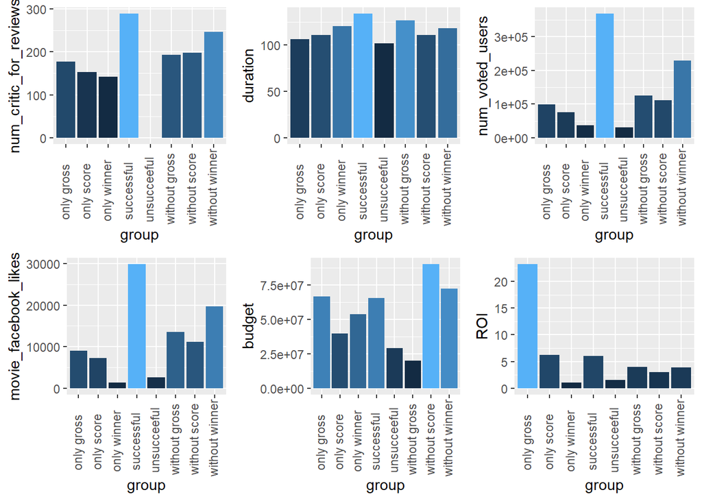

```r
p1 = ggplot(aes(x = means_df$`group name`, y = num_critic_for_reviews,fill=num_critic_for_reviews), data = means_df) +
  geom_bar(stat = 'identity') +labs(x = "group")+theme(legend.position = "none",axis.text.x = element_text(angle = 90, vjust = 0.3, hjust=0.3))
p2 = ggplot(aes(x = means_df$`group name`, y = duration ,fill=duration), data = means_df) +
  geom_bar(stat = 'identity') +
 labs(x = "group")+theme(legend.position = "none",axis.text.x = element_text(angle = 90, vjust = 0.3, hjust=0.3))
p3 = ggplot(aes(x = means_df$`group name`, y = num_voted_users
,fill=num_voted_users
), data = means_df) +
  geom_bar(stat = 'identity') +
 labs(x = "group")+theme(legend.position = "none",axis.text.x = element_text(angle = 90, vjust = 0.3, hjust=0.3))
p4 = ggplot(aes(x = means_df$`group name`, y = movie_facebook_likes,fill=movie_facebook_likes), data = means_df) +
  geom_bar(stat = 'identity') +
 labs(x = "group")+theme(legend.position = "none",axis.text.x = element_text(angle = 90, vjust = 0.3, hjust=0.3))
p5 = ggplot(aes(x = means_df$`group name`, y = budget,fill=budget), data = means_df) +
  geom_bar(stat = 'identity') +
 labs(x = "group")+theme(legend.position = "none",axis.text.x = element_text(angle = 90, vjust = 0.3, hjust=0.3))
p6 = ggplot(aes(x = means_df$`group name`, y = ROI,fill=ROI), data = means_df) +
  geom_bar(stat = 'identity') +
 labs(x = "group")+theme(legend.position = "none",axis.text.x = element_text(angle = 90, vjust = 0.3, hjust=0.3))
ggarrange(p1, p2,p3,p4,p5,p6, widths = c(10,10,10,10,10,10))
```

Now, we will summarize some main insights from those charts:

- There is a correlation between successful movies to successful movies that did not win the Oscar in almost all parameters. as we mentioned above, there is not many observation for winner award movies and that is the reason.
- All the social impact parameters, such as, movie facebook likes, votes and reviews are much higher in successful movies than all the other groups, even a lot more than successful movies that did not win the Oscar. That is make sense, successful movies have higher social exposure and apparently that Oscar title has a big impact on it.
- There is not correlation between budget and ROI, which means that production that invested more than others are not have to be more profitability. In addition, the group that invested the most has lower imdb score than others, so higher investment do not insure better score.

As we can see, there is many insights we can find in our data and we will keep investigating these insights and others in the rest of our project.

In the next charts we will try to find connection to genres.

Let’s make a scatter plot showing the worldwide gross revenue over the production budget. Let’s make the color of the point relative to whether the movie won an Oscar title or not. Let’s add a “breakeven” line that has a slope of 1 and a y-intercept of zero. Let’s facet by genre.

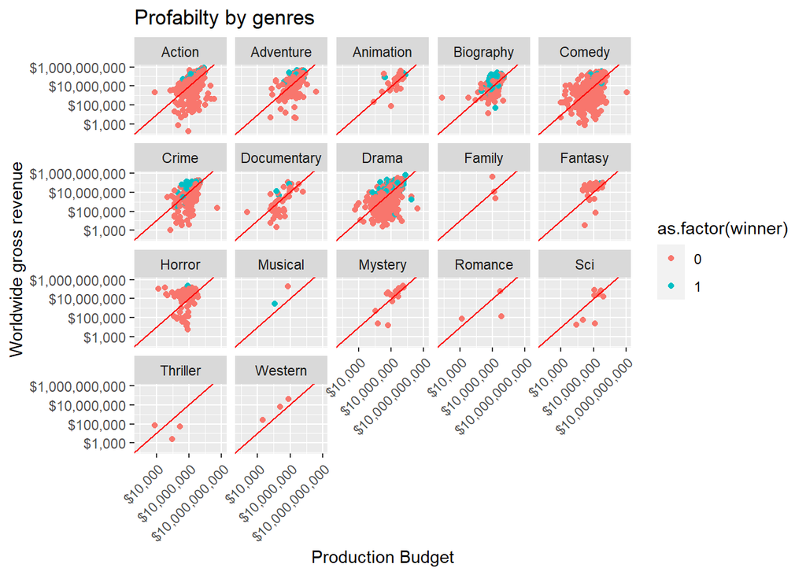

```r
movies %>%
  ggplot(aes(budget, gross)) +
  geom_point(aes(col = as.factor(winner))) +
  geom_abline(slope = 1, intercept = 0, col = "red") +
  facet_wrap( ~ genres) +
  scale_x_log10(labels = dollar_format()) +
  scale_y_log10(labels = dollar_format()) +
  theme(axis.text.x = element_text(angle = 45, hjust = 1)) +
  labs(title="Profabilty by genres",x = "Production Budget",
       y = "Worldwide gross revenue",
       size = "Return on Investment")
```

Generally it seems that the points distribution is around the “breakeven” line. It is make a little sense - if movies weren’t profitable at all they wouldn’t keep making them but there is many movies that can not return all the investment they invested, and that is why we are here :) Another insight from this plot is that Proportionally there seem to be many more blue points (which indicate won) above the line, so it seems that movies that won the Oscar are more profitable.

In addition to our groups of data, we tried to find any correlation or important insights from our factors, directors and actor, to success.

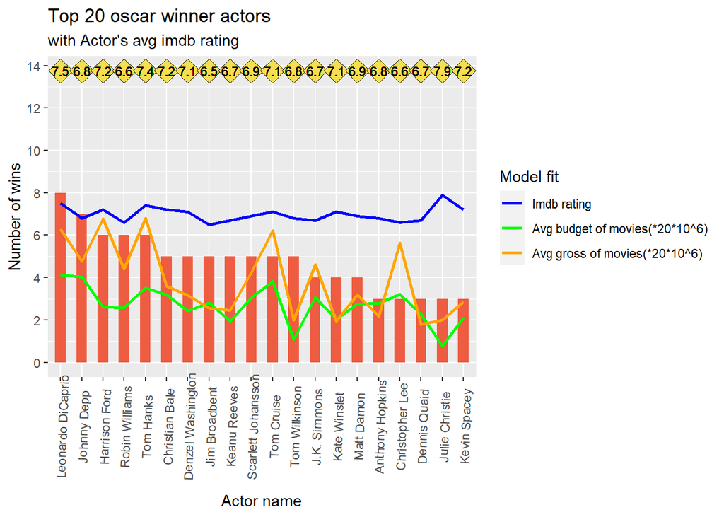

```r
actor <- (movies %>%
            group_by(main_actor) %>%
            summarise(num_of_win = sum(winner),imdb_score_avg = round(mean(imdb_score),1),gross = mean(gross),budget = mean(budget))%>%
            filter(num_of_win >= 2)%>% arrange(desc(num_of_win)) )[1:20,]


p = ggplot(actor, aes(x = reorder(main_actor, -num_of_win), num_of_win), group=1)+
geom_bar(stat="identity", width = 0.5, fill="tomato2") +
      labs(title="Top 20 oscar winner actors",subtitle ="with Actor's avg imdb rating", y = "Number of wins", x = "Actor name") +
geom_line(aes(x = main_actor, imdb_score_avg, group=1))+
geom_line(aes(x = main_actor, imdb_score_avg, group=1,color = "blue"),size = 1)+
geom_line(aes(x = main_actor, budget/20000000, group=1, color = "green"),size = 1)+
geom_line(aes(x = main_actor, gross/20000000, group=1, color = "orange"),size = 1)+
scale_color_identity(name = "Model fit",
                          breaks = c("blue", "green", "orange"),
                          labels = c("Imdb rating", "Avg budget of movies(*20*10^6)", "Avg gross of movies(*20*10^6)"),
                          guide = "legend") +
      theme(axis.text.x = element_text(angle=88, vjust=0.6)) +
  xlab("Actor name")
p <- p + geom_point(aes(y=13.75), shape = 23, size = 6, fill = "#f5de50")
for(i in 1:length(actor$imdb_score_avg)){p <- p + geom_text(x=i, y=13.75,size = 3, label=actor$imdb_score_avg[i])}

p + scale_y_continuous(breaks=seq(0,20,2))
```

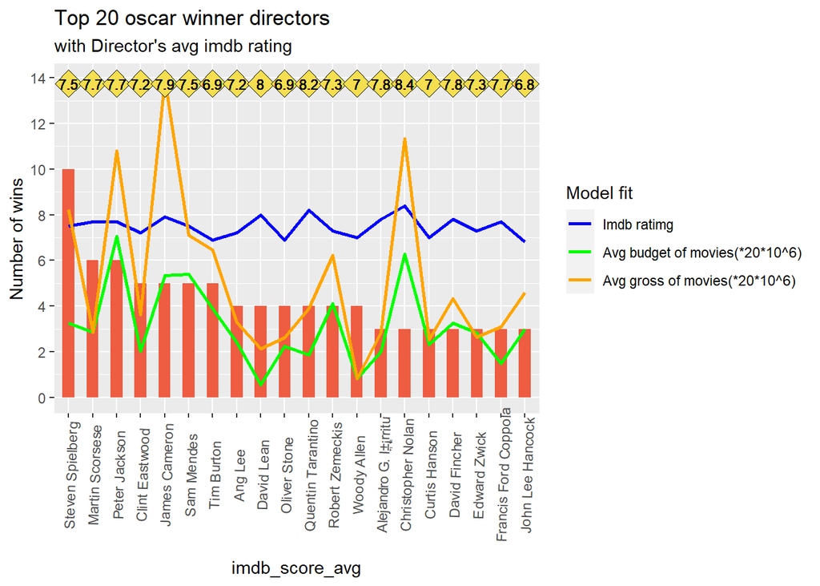

```r
director <- (movies %>%
            group_by(director_name) %>%
            summarise(num_of_win = sum(winner),imdb_score_avg = round(mean(imdb_score),1),gross = mean(gross),budget = mean(budget))%>%
            filter(num_of_win >= 2)%>% arrange(desc(num_of_win)) )[1:20,]


p = ggplot(director, aes(x = reorder(director_name, -num_of_win), num_of_win), group=1)+
geom_bar(stat="identity", width = 0.5, fill="tomato2") +
      labs(title="Top 20 oscar winner directors",subtitle ="with Director's avg imdb rating", y = "Number of wins", x = "Director name") +
geom_line(aes(x = director_name, imdb_score_avg, group=1))+
geom_line(aes(x = director_name, imdb_score_avg, group=1,color = "blue"),size = 1)+
geom_line(aes(x = director_name, budget/20000000, group=1, color = "green"),size = 1)+
geom_line(aes(x = director_name, gross/20000000, group=1, color = "orange"),size = 1)+
scale_color_identity(name = "Model fit",
                          breaks = c("blue", "green", "orange"),
                          labels = c("Imdb ratimg", "Avg budget of movies(*20*10^6)", "Avg gross of movies(*20*10^6)"),
                          guide = "legend") +
      theme(axis.text.x = element_text(angle=88, vjust=0.6)) +
  xlab("imdb_score_avg")
p <- p + geom_point(aes(y=13.75), shape = 23, size = 6, fill = "#f5de50")
for(i in 1:length(director$imdb_score_avg)){p <- p + geom_text(x=i, y=13.75,size = 3, label=director$imdb_score_avg[i])}

p + scale_y_continuous(breaks=seq(0,20,2))
```

as we can see, there is a connection between budget and gross, but rather than that there is not bold indication from each of the graphs, so these three factors depends on other factors from our data and our work is to find out which of them is the most important.

The feature of director and actor’s name also has a large depth. Those variables are hard to fit in most algorithms and we have not seen any analysis that paid any attention to those variables. Therefore, we came up with an idea that doesn’t use the variables names , but keeps the useful information in the name features at the same time. Different Actors and Directors have different box office appeal and IMDB score, and it changes over time. The box office appeal and IMDB rating can be represented by history gross and IMDB Score. Generating these factors can be a key factor for predicting their next movie.

## 4. Data analysis plan

We believe that our vision of success movie parameters is something new, that has not been done yet, and our division of groups, successful in all the three parametrs, only in two, etc, will lead us to many new insights about future movies.

Teamwork:

The project is going to be divided according to individual tasks and responsibilities but in mutual sharing of information between the different paths of each of us at each stage of the project.

Division of responsibilities:

Amit B - Responsible for machine learning algorithm and web scrapping in the project Yonatan - Responsible for data analysis and combining all the insights in the project Amit F- responsible for researches and data analysis in the project

## Appendix

Datesets :

https://www.kaggle.com/datasets/carolzhangdc/imdb-5000-movie-dataset?select=movie_metadata.csv https://www.kaggle.com/datasets/unanimad/the-oscar-award

code for scarpping the data:

Movies_file_5000[‘mounth’] <- NA

FUN <- function(x){ Sys.sleep(5) movie_1 <- read_html(x) mounth <- html_nodes(movie_1,” li a “) %>% html_text() word(mounth[which(mounth == “Release date”) + 1],1)

}

Movies_file_5000$mounth <- lapply(Movies_file_5000$movie_imdb_link, FUN)

### Source code

```r
knitr::opts_chunk$set(
    echo = TRUE, # show all code
    tidy = FALSE, # cleaner code printing
    size = "small", # smaller code

    fig.path = "figures/", #graphics location
    out.width = "100%",

    message = FALSE,
    warning = FALSE
    )

library(knitr)
library(tidyverse)
library(broom)
library(htmltools)
library(ggrepel)
library(ggpubr)
library(stringr)
library(scales)
library(lubridate)
library(gganimate)
library(gapminder)
library(GGally)
library(cowplot)
undesired <- c('color','actor_3_facebook_likes',"actor_2_name","actor_3_name","facenumber_in_poster","plot_keywords" ,"movie_imdb_link","num_user_for_reviews","language","country","actor_2_facebook_likes","aspect_ratio")

Oscar_file <- read.csv('../data/the_oscar_award.csv')%>% rename(movie_title = film)%>%
select(movie_title,winner) %>%
filter(winner == "True") %>% distinct()  #filter Oscar winners

Movies_file_5000 <- read.csv('../data/movie_metadata.csv')
Movies_file_5000$movie_title <- substring(Movies_file_5000$movie_title, 1, nchar(Movies_file_5000$movie_title)-2)  ##remove suffix from movie title

movies = merge(x = Movies_file_5000, y =  Oscar_file, by = "movie_title", all.x = TRUE) %>%
select(-one_of(undesired)) %>%
mutate(ROI = (gross/budget)) #join and remove/add columns

movies["winner"][is.na(movies["winner"])] <- 0
movies["winner"][movies["winner"] == "True"] <- 1
movies = movies %>% drop_na(gross) %>% drop_na(budget)

movies$genres = str_extract(movies$genres,"(\\w+)") # extract only one genre
movies$winner = as.numeric(as.character(movies$winner))
movies =  movies %>% rename(main_actor = actor_1_name, main_actor_facebook_likes = actor_1_facebook_likes)

mean_gross = mean(movies$gross)
mean_imdb = round(mean(movies$imdb_score),3)

movies$succeed = ifelse(movies$gross < mean_gross,0,
                        ifelse(movies$imdb_score < mean_imdb,0,
                               ifelse(movies$winner != 1,0,1)))

glimpse(movies)
cat(readLines('../data/README.md'), sep = '\n')
cat("The data contain",ncol(movies), "variables")
cat("\n")
cat("The data contain",nrow(movies), "movies")
cat("The number of Oscar winner movies is:",sum(movies$winner))
cat("\n")
cat("The mean gross is:",mean_gross, "$")
cat("\n")
cat("The mean IMDB score is:",mean_imdb)
cat("\n")
cat("The number of successful movies is:",sum(movies$succeed))


## best film in account of gross,ROI,imdb rating, oscar winner
best_movies = (movies %>%
            filter(gross >= mean_gross,imdb_score >= mean_imdb,winner == 1) )

# two succeed parameters from three
two_from_three_no_winner = movies %>%
              filter((gross >= mean_gross) & (imdb_score >= mean_imdb) & (winner == 0))

two_from_three_no_gross = movies %>%
  filter((gross < mean_gross) & (imdb_score >= mean_imdb) & (winner == 1))

two_from_three_no_score = movies %>%
  filter((gross >= mean_gross) & (imdb_score < mean_imdb) & (winner == 1))

#one succeed parameter
winner_one = movies %>%
              filter((gross < mean_gross) & (imdb_score < mean_imdb) & (winner == 1))
score_one = movies %>%
              filter((gross < mean_gross) & (imdb_score >= mean_imdb) & (winner == 0))
gross_one = movies %>%
              filter((gross >= mean_gross) & (imdb_score < mean_imdb) & (winner == 0))

## all other movies
not_best_movies = (movies %>%
            filter(gross < mean_gross,imdb_score < mean_imdb) )%>% drop_na(duration)

## get numric columns
num_cols1 <- unlist(lapply(best_movies, is.numeric))
num_cols2 <- unlist(lapply(two_from_three_no_winner, is.numeric))
num_cols3 <- unlist(lapply(two_from_three_no_score, is.numeric))
num_cols4 <- unlist(lapply(two_from_three_no_gross, is.numeric))
num_cols5 <- unlist(lapply(winner_one, is.numeric))
num_cols6 <- unlist(lapply(score_one, is.numeric))
num_cols7 <- unlist(lapply(gross_one, is.numeric))
num_cols8 <- unlist(lapply(not_best_movies, is.numeric))

numric_cols1 <- best_movies[ , num_cols1]
numric_cols2 <- two_from_three_no_winner[ , num_cols2]
numric_cols3 <- two_from_three_no_score[ , num_cols3]
numric_cols4 <- two_from_three_no_gross[ , num_cols4]
numric_cols5 <- winner_one[ , num_cols5]
numric_cols6 <- score_one[ , num_cols6]
numric_cols7 <- gross_one[ , num_cols7]
numric_cols8 <- not_best_movies[ , num_cols8]


best_movies_means = (as.data.frame.list(colMeans(numric_cols1)))
two_from_three_no_winner_means = (as.data.frame.list(colMeans(numric_cols2)))
two_from_three_no_score_means = (as.data.frame.list(colMeans(numric_cols3)))
two_from_three_no_gross_means = (as.data.frame.list(colMeans(numric_cols4)))
winner_one_means = (as.data.frame.list(colMeans(numric_cols5)))
score_one_means = (as.data.frame.list(colMeans(numric_cols6)))
gross_one_means = (as.data.frame.list(colMeans(numric_cols7)))
not_best_movies_means = (as.data.frame.list(colMeans(numric_cols8)))


## combine dfs
means_df = best_movies_means
means_df[nrow(means_df) + 1,] <- head(two_from_three_no_winner_means,1)
means_df[nrow(means_df) + 1,] <- head(two_from_three_no_score_means,1)
means_df[nrow(means_df) + 1,] <- head(two_from_three_no_gross_means,1)
means_df[nrow(means_df) + 1,] <- head(winner_one_means,1)
means_df[nrow(means_df) + 1,] <- head(score_one_means,1)
means_df[nrow(means_df) + 1,] <- head(gross_one_means,1)
means_df[nrow(means_df) + 1,] <- head(not_best_movies_means,1)


means_df['group name'] = c('successful','without winner','without score','without gross','only winner','only score','only gross','unsucceeful')

means_df <- subset(means_df, select=c(15,1,2,3,4,6,7,8,11,13))

means_df

p1 = ggplot(aes(x = means_df$`group name`, y = num_critic_for_reviews,fill=num_critic_for_reviews), data = means_df) +
  geom_bar(stat = 'identity') +labs(x = "group")+theme(legend.position = "none",axis.text.x = element_text(angle = 90, vjust = 0.3, hjust=0.3))
p2 = ggplot(aes(x = means_df$`group name`, y = duration ,fill=duration), data = means_df) +
  geom_bar(stat = 'identity') +
 labs(x = "group")+theme(legend.position = "none",axis.text.x = element_text(angle = 90, vjust = 0.3, hjust=0.3))
p3 = ggplot(aes(x = means_df$`group name`, y = num_voted_users
,fill=num_voted_users
), data = means_df) +
  geom_bar(stat = 'identity') +
 labs(x = "group")+theme(legend.position = "none",axis.text.x = element_text(angle = 90, vjust = 0.3, hjust=0.3))
p4 = ggplot(aes(x = means_df$`group name`, y = movie_facebook_likes,fill=movie_facebook_likes), data = means_df) +
  geom_bar(stat = 'identity') +
 labs(x = "group")+theme(legend.position = "none",axis.text.x = element_text(angle = 90, vjust = 0.3, hjust=0.3))
p5 = ggplot(aes(x = means_df$`group name`, y = budget,fill=budget), data = means_df) +
  geom_bar(stat = 'identity') +
 labs(x = "group")+theme(legend.position = "none",axis.text.x = element_text(angle = 90, vjust = 0.3, hjust=0.3))
p6 = ggplot(aes(x = means_df$`group name`, y = ROI,fill=ROI), data = means_df) +
  geom_bar(stat = 'identity') +
 labs(x = "group")+theme(legend.position = "none",axis.text.x = element_text(angle = 90, vjust = 0.3, hjust=0.3))
ggarrange(p1, p2,p3,p4,p5,p6, widths = c(10,10,10,10,10,10))

movies %>%
  ggplot(aes(budget, gross)) +
  geom_point(aes(col = as.factor(winner))) +
  geom_abline(slope = 1, intercept = 0, col = "red") +
  facet_wrap( ~ genres) +
  scale_x_log10(labels = dollar_format()) +
  scale_y_log10(labels = dollar_format()) +
  theme(axis.text.x = element_text(angle = 45, hjust = 1)) +
  labs(title="Profabilty by genres",x = "Production Budget",
       y = "Worldwide gross revenue",
       size = "Return on Investment")
actor <- (movies %>%
            group_by(main_actor) %>%
            summarise(num_of_win = sum(winner),imdb_score_avg = round(mean(imdb_score),1),gross = mean(gross),budget = mean(budget))%>%
            filter(num_of_win >= 2)%>% arrange(desc(num_of_win)) )[1:20,]


p = ggplot(actor, aes(x = reorder(main_actor, -num_of_win), num_of_win), group=1)+
geom_bar(stat="identity", width = 0.5, fill="tomato2") +
      labs(title="Top 20 oscar winner actors",subtitle ="with Actor's avg imdb rating", y = "Number of wins", x = "Actor name") +
geom_line(aes(x = main_actor, imdb_score_avg, group=1))+
geom_line(aes(x = main_actor, imdb_score_avg, group=1,color = "blue"),size = 1)+
geom_line(aes(x = main_actor, budget/20000000, group=1, color = "green"),size = 1)+
geom_line(aes(x = main_actor, gross/20000000, group=1, color = "orange"),size = 1)+
scale_color_identity(name = "Model fit",
                          breaks = c("blue", "green", "orange"),
                          labels = c("Imdb rating", "Avg budget of movies(*20*10^6)", "Avg gross of movies(*20*10^6)"),
                          guide = "legend") +
      theme(axis.text.x = element_text(angle=88, vjust=0.6)) +
  xlab("Actor name")
p <- p + geom_point(aes(y=13.75), shape = 23, size = 6, fill = "#f5de50")
for(i in 1:length(actor$imdb_score_avg)){p <- p + geom_text(x=i, y=13.75,size = 3, label=actor$imdb_score_avg[i])}

p + scale_y_continuous(breaks=seq(0,20,2))



director <- (movies %>%
            group_by(director_name) %>%
            summarise(num_of_win = sum(winner),imdb_score_avg = round(mean(imdb_score),1),gross = mean(gross),budget = mean(budget))%>%
            filter(num_of_win >= 2)%>% arrange(desc(num_of_win)) )[1:20,]


p = ggplot(director, aes(x = reorder(director_name, -num_of_win), num_of_win), group=1)+
geom_bar(stat="identity", width = 0.5, fill="tomato2") +
      labs(title="Top 20 oscar winner directors",subtitle ="with Director's avg imdb rating", y = "Number of wins", x = "Director name") +
geom_line(aes(x = director_name, imdb_score_avg, group=1))+
geom_line(aes(x = director_name, imdb_score_avg, group=1,color = "blue"),size = 1)+
geom_line(aes(x = director_name, budget/20000000, group=1, color = "green"),size = 1)+
geom_line(aes(x = director_name, gross/20000000, group=1, color = "orange"),size = 1)+
scale_color_identity(name = "Model fit",
                          breaks = c("blue", "green", "orange"),
                          labels = c("Imdb ratimg", "Avg budget of movies(*20*10^6)", "Avg gross of movies(*20*10^6)"),
                          guide = "legend") +
      theme(axis.text.x = element_text(angle=88, vjust=0.6)) +
  xlab("imdb_score_avg")
p <- p + geom_point(aes(y=13.75), shape = 23, size = 6, fill = "#f5de50")
for(i in 1:length(director$imdb_score_avg)){p <- p + geom_text(x=i, y=13.75,size = 3, label=director$imdb_score_avg[i])}

p + scale_y_continuous(breaks=seq(0,20,2))
```